# Stage 2a: two-country linked pilot

Germany and France in one koma system – proving the linkage mechanism before scaling to eleven

## 1. The system

Everything below is a single `koma::system_of_equations()` call: 21 equations, 13 stochastic and 8 identities, no external packages and no per-country loop over `estimate()`.

```
de_consumption~constant+de_gdp+de_consumption.L(1),
de_investment~constant+de_gdp+de_long_rate+de_investment.L(1),
de_exports~constant+de_foreign_demand+de_exports.L(1),
de_imports~constant+de_domestic_demand+de_imports.L(1),
de_prices~constant+eur_usd+oil_price+de_prices.L(1),
de_long_rate~constant+de_prices+ea_policy_rate+de_gdp+de_long_rate.L(1),
fr_consumption~constant+fr_gdp+fr_consumption.L(1),
fr_investment~constant+fr_gdp+fr_long_rate+fr_investment.L(1),
fr_exports~constant+fr_foreign_demand+fr_exports.L(1),
fr_imports~constant+fr_domestic_demand+fr_imports.L(1),
fr_prices~constant+eur_usd+oil_price+fr_prices.L(1),
fr_long_rate~constant+fr_prices+ea_policy_rate+fr_gdp+fr_long_rate.L(1),
ea_policy_rate~constant+ea_prices+ea_gdp+ea_policy_rate.L(1),
de_gdp==0.937*de_domestic_demand+0.369*de_exports-0.314*de_imports,
de_domestic_demand==0.585*de_consumption+0.211*de_investment+0.204*de_government,
de_foreign_demand==0.065*fr_gdp+0.935*row_gdp,
fr_gdp==0.988*fr_domestic_demand+0.291*fr_exports-0.284*fr_imports,
fr_domestic_demand==0.545*fr_consumption+0.218*fr_investment+0.237*fr_government,
fr_foreign_demand==0.139*de_gdp+0.861*row_gdp,
ea_gdp==0.604*de_gdp+0.396*fr_gdp,
ea_prices==0.604*de_prices+0.396*fr_prices
```

Three things differ from stage 1, and each is deliberate:

1. **Exports are driven by `<iso2>_foreign_demand`**, a fixed-weight identity over the *other country’s endogenous GDP*. Stage 1 used the exogenous `row_gdp`, which excludes every modelled economy — so intra-EA export demand was missing entirely.
2. **`ea_policy_rate` is endogenous**, with a Taylor-type rule over GDP-weighted `ea_gdp` / `ea_prices` identities.
3. **`<iso2>_long_rate` enters investment.** This is what actually gives the policy rate a route to GDP — see §4.

### Endogenous vs exogenous, as koma parses them

How koma parses the system. Note identity left-hand sides are endogenous.

|  | n | variables |
| --- | --- | --- |
| endogenous | 21 | de_consumption, de_investment, de_exports, de_imports, de_prices, de_long_rate, fr_consumption, fr_investment, fr_exports, fr_imports, fr_prices, fr_long_rate, ea_policy_rate, de_gdp, de_domestic_dema… |
| stochastic equations | 13 | de_consumption, de_investment, de_exports, de_imports, de_prices, de_long_rate, fr_consumption, fr_investment, fr_exports, fr_imports, fr_prices, fr_long_rate, ea_policy_rate |
| identities | 8 | de_gdp, de_domestic_demand, de_foreign_demand, fr_gdp, fr_domestic_demand, fr_foreign_demand, ea_gdp, ea_prices |
| exogenous | 5 | eur_usd, oil_price, de_government, row_gdp, fr_government |
| predetermined | 13 | de_consumption.L1, de_investment.L1, de_exports.L1, de_imports.L1, de_prices.L1, de_long_rate.L1, fr_consumption.L1, fr_investment.L1, fr_exports.L1, fr_imports.L1, fr_prices.L1, fr_long_rate.L1, ea_p… |

The exogenous set is **five**, not the three truly-global variables. `<iso2>_government` has no equation of its own (fiscal policy is a given, as in stage 1) but does appear in the domestic-demand identities. koma’s `validate_completeness()` is an **exact-set** check — an undeclared variable aborts, and so does a declared-but-unused one — so this set is neither a subset nor a superset of what is used.

### Linkage weights

Each modelled partner keeps its true W_trade weight; everything else lumps into row_gdp.

| identity | weights |
| --- | --- |
| de_foreign_demand | fr_gdp 0.065, row_gdp 0.935 |
| fr_foreign_demand | de_gdp 0.139, row_gdp 0.861 |
| ea_gdp / ea_prices | de 0.604, fr 0.396 |

**Documented approximation.** `build_row_gdp()` excludes all eleven modelled economies by construction, so in a two-country pilot the 0.935 weight on `row_gdp` is proxying the nine *absent modelled* partners (0.374 of German trade) as well as genuine rest-of-world. This shrinks monotonically as countries are added — each new country claims its own `W_trade` weight out of the `row` residual, and no other weight is rescaled.

The immediate consequence is that **the DE↔︎FR channel is small by construction**: France is only 6.5% of German trade. §5 shows that this is exactly what the estimates say.

### The four constructed series

`koma::estimate()` requires a series for *every* endogenous variable, identity- defined ones included, and only says so from inside `estimate()`. Four have no observed counterpart: `de_foreign_demand`, `fr_foreign_demand`, `ea_gdp`, `ea_prices`.

They are built with `chain_weighted_index()`, **not** `apply_weights()`, because koma estimates on growth rates: an identity is a statement about `diff(log())`, and `log(0.6a + 0.4b) != 0.6*log(a) + 0.4*log(b)`. A level-space aggregate would leave the estimator reading one relationship out of the data while the identity’s `Gamma` column encodes another — silently, since koma performs no identity-consistency check. For `de_foreign_demand` the two constructions differ by up to **13.7 percentage points** of quarterly growth. The chained version reproduces its identity to 8.5e-14.

## 2. Pre-flight

All checks run before committing to estimation.

| check | ok | detail |
| --- | --- | --- |
| identity RHS variables all resolve | TRUE | - |
| no variable defined twice | TRUE | - |
| every variable has a panel series | TRUE | 26 variables present |
| no internal NAs in required series | TRUE | - |
| identities declared last | TRUE | 13 stochastic then 8 identities |
| system identified | TRUE | 10/10 seeds pass order + rank |

`model_identification()` fills free coefficients with `rnorm` draws, so a single pass proves very little — it is repeated across 10 seeds, and passes the order **and** rank conditions on all of them.

The “identities declared last” check is not cosmetic. koma assumes it positionally in two places (`model_identification()` loops `for (j in seq(1, n_endogenous - n_identities))` over columns, and `estimate_sem()` indexes `y_matrix[, jx]` by the same index), so an identity declared anywhere else makes koma estimate the wrong columns and mislabel the results **with no error**. This is undocumented; every example koma ships obeys it.

## 3. Runtime and acceptance rates

Estimated in **65.3 s** (13 stochastic equations, 78 observations, koma defaults: `ndraws = 2000`, `burnin_ratio = 0.5`, `tau = 1.1`). koma fans out one future per stochastic equation.

Acceptance rates at the default tau = 1.1. Band is 20-60% (koma:::get_default_acceptance_prob()).

| equation | has_mh_step | acceptance_rate | flagged |
| --- | --- | --- | --- |
| de_consumption | TRUE | 0.6065 | TRUE |
| de_investment | TRUE | 0.4235 | FALSE |
| de_exports | TRUE | 0.5900 | FALSE |
| de_imports | TRUE | 0.6020 | TRUE |
| de_prices | FALSE | NA | FALSE |
| de_long_rate | TRUE | 0.2865 | FALSE |
| fr_consumption | TRUE | 0.6050 | TRUE |
| fr_investment | TRUE | 0.4015 | FALSE |
| fr_exports | TRUE | 0.6015 | TRUE |
| fr_imports | TRUE | 0.5920 | FALSE |
| fr_prices | FALSE | NA | FALSE |
| fr_long_rate | TRUE | 0.2780 | FALSE |
| ea_policy_rate | TRUE | 0.3925 | FALSE |

`de_prices` and `fr_prices` show `NA`: they have **no contemporaneous endogenous regressor**, so there is no `gamma` block and no Metropolis step at all. They are correctly not flagged.

Four equations sat marginally over the 60% ceiling. One tuning round at `tau = 2.2` (koma’s rule of thumb: doubling `tau` roughly halves acceptance) cleared all four:

Before/after one tau round: 4 flagged -> 0.

| equation | tau | acceptance_rate_before | flagged_before | acceptance_rate_after | flagged_after |
| --- | --- | --- | --- | --- | --- |
| de_consumption | 2.2 | 0.6065 | TRUE | 0.4090 | FALSE |
| de_imports | 2.2 | 0.6020 | TRUE | 0.4235 | FALSE |
| fr_consumption | 2.2 | 0.6050 | TRUE | 0.4055 | FALSE |
| fr_exports | 2.2 | 0.6015 | TRUE | 0.4010 | FALSE |
| de_exports | 1.1 | 0.5900 | FALSE | 0.5900 | FALSE |
| de_investment | 1.1 | 0.4235 | FALSE | 0.4235 | FALSE |
| de_long_rate | 1.1 | 0.2865 | FALSE | 0.2865 | FALSE |
| de_prices | 1.1 | NA | FALSE | NA | FALSE |
| ea_policy_rate | 1.1 | 0.3925 | FALSE | 0.3925 | FALSE |
| fr_imports | 1.1 | 0.5920 | FALSE | 0.5920 | FALSE |
| fr_investment | 1.1 | 0.4015 | FALSE | 0.4015 | FALSE |
| fr_long_rate | 1.1 | 0.2780 | FALSE | 0.2780 | FALSE |
| fr_prices | 1.1 | NA | FALSE | NA | FALSE |

Worth noting for its own sake: the nine untouched equations’ acceptance rates are **bit-identical** before and after, confirming koma’s documented claim that a per-equation `[tau = ]` override leaves the rest of the system alone.

## 4. Does the policy rate reach GDP?

The stage-1 diagnostics report closed on a structural finding: a policy-rate shock could not move GDP, because `long_rate` was a terminal satellite equation. Making `ea_policy_rate` endogenous does **not** on its own fix that — traced on the contemporaneous `Gamma` graph, a policy rate with no investment channel reaches only `de_long_rate` and `fr_long_rate`, and stops.

Adding `<iso2>_long_rate` to the investment equation is what closes the loop:

Contemporaneous reachability on the Gamma matrix.

| from | reaches | includes_fr_gdp | detail |
| --- | --- | --- | --- |
| ea_policy_rate | 17 | TRUE | de_consumption, de_domestic_demand, de_exports, de_foreign_demand, de_gdp, de_imports, de_investment, de_long_rate, ea_gdp, fr_consumption, fr_domestic_demand, fr_exports, fr_foreign_demand, fr_gdp, f… |
| de_gdp | 17 | TRUE | (full cycle) |

The cross-country cycle asked for is present and closed: `de_gdp → fr_foreign_demand → fr_exports → fr_gdp → de_foreign_demand → de_exports → de_gdp`.

**Is that well-posed?** Yes, and estimation and forecasting stress different things:

- **Estimation** is limited-information and equation-by-equation (`draw_parameters_j`). Contemporaneous endogenous regressors are read from the *observed* `y_matrix`; koma never inverts `Gamma` while sampling. A cycle is the ordinary simultaneous-equations case. The binding constraint is identification, checked symbolically before any data is touched — and it passes.
- **Forecasting** is where a bad loop would bite: the reduced form is `B %*% solve(Gamma)`, so `Gamma` must be invertible. Measured `det(Gamma)` stays in 0.31–1.11 across rate→investment coefficients of −10…+5 and Taylor gains 0…5. The economically-correct *negative* rate→investment sign moves it **away** from singularity, since a negative feedback loop is stabilising.

Had it not been well-posed there would have been three distinct failure modes: under-identification aborts up front (cheap, loud); a singular `Gamma` throws a bare base-R `solve()` error at forecast time; and a *near*-singular `Gamma` throws nothing at all and silently returns explosive forecasts. koma has no cycle, stability or eigenvalue check anywhere, so the third is the dangerous one. Here the cross-country loop gain is ≈0.369 × 0.065 × 0.291 × 0.139 ≈ **0.001** — three orders of magnitude from 1.

## 5. Comparison against the stage-1 standalone DE and FR fits

Three of six equations per country are structurally identical to stage 1 and three were respecified. Only the identical ones isolate what *joint estimation* did, so they are reported separately — treating the others as comparable would attribute a respecification to the linkage.

Which equations can be compared at all.

| equation | vs stage 1 | comparable |
| --- | --- | --- |
| consumption | identical | yes |
| imports | identical | yes |
| prices | identical | yes |
| investment | gained _long_rate | no |
| exports | row_gdp -> _foreign_demand | no |
| long_rate | gained _gdp | no |

### The clean comparison

Structurally identical equations: posterior mean and 90% interval.

| equation | term | stage1 | stage2a | delta | outside stage-1 90% CI |
| --- | --- | --- | --- | --- | --- |
| de_consumption | constant | 0.238 [0.12, 0.36] | 0.238 [0.11, 0.37] | 0.000 | - |
| de_consumption | de_consumption.L1 | -0.212 [-0.42, 0.01] | -0.207 [-0.40, -0.01] | 0.005 | - |
| de_consumption | de_gdp | 0.118 [-0.07, 0.30] | 0.124 [-0.05, 0.31] | 0.007 | - |
| de_imports | constant | 0.643 [0.12, 1.20] | 0.532 [-0.03, 1.12] | -0.111 | - |
| de_imports | de_domestic_demand | 0.059 [-1.05, 1.18] | 0.743 [-0.53, 2.03] | 0.684 | - |
| de_imports | de_imports.L1 | 0.224 [0.00, 0.46] | 0.170 [-0.05, 0.39] | -0.054 | - |
| de_prices | constant | 0.311 [0.22, 0.39] | 0.316 [0.23, 0.40] | 0.005 | - |
| de_prices | de_prices.L1 | 0.187 [0.03, 0.34] | 0.181 [0.01, 0.35] | -0.006 | - |
| de_prices | eur_usd | -0.014 [-0.03, 0.00] | -0.014 [-0.03, 0.00] | 0.000 | - |
| de_prices | oil_price | 0.014 [0.01, 0.02] | 0.014 [0.01, 0.02] | 0.000 | - |
| fr_consumption | constant | 0.238 [0.12, 0.37] | 0.227 [0.11, 0.35] | -0.011 | - |
| fr_consumption | fr_consumption.L1 | 0.079 [-0.12, 0.28] | 0.059 [-0.13, 0.26] | -0.020 | - |
| fr_consumption | fr_gdp | 0.303 [0.04, 0.57] | 0.362 [0.12, 0.59] | 0.059 | - |
| fr_imports | constant | 0.023 [-0.53, 0.58] | -0.254 [-0.79, 0.24] | -0.277 | - |
| fr_imports | fr_domestic_demand | 1.725 [0.34, 3.11] | 2.633 [1.45, 3.96] | 0.909 | - |
| fr_imports | fr_imports.L1 | 0.123 [-0.06, 0.32] | 0.064 [-0.13, 0.25] | -0.059 | - |
| fr_prices | constant | 0.255 [0.18, 0.32] | 0.254 [0.18, 0.33] | -0.001 | - |
| fr_prices | eur_usd | -0.008 [-0.02, 0.00] | -0.007 [-0.02, 0.01] | 0.001 | - |
| fr_prices | fr_prices.L1 | 0.332 [0.19, 0.47] | 0.335 [0.19, 0.47] | 0.002 | - |
| fr_prices | oil_price | 0.014 [0.01, 0.02] | 0.014 [0.01, 0.02] | 0.000 | - |

**0 of 20** coefficients in the identical equations moved outside their stage-1 90% interval.

### Where they differ, and why

Three distinct patterns, and the mechanism for each is visible in koma’s sampler rather than inferred:

**`prices` does not move at all** (deltas 0.000–0.006, i.e. Monte Carlo noise). It is the one equation with no contemporaneous endogenous regressor, so `draw_omega_j` takes its `number_endogenous_in_j == 0` branch, which uses only the equation’s *own* restricted regressor columns. Nothing about the wider system can reach it. This is a useful control: it confirms the differences elsewhere are a real estimation effect and not a change of sample, vintage or seed handling.

**`consumption` moves slightly** (`de_gdp` +0.007, `fr_gdp` +0.059).

**`imports` moves most** — `de_domestic_demand` 0.059 → 0.743, `fr_domestic_demand` 1.725 → 2.633.

The mechanism is the **instrument set, not the trade loop**. koma’s sampler is limited-information, but the `gamma` block of any equation with a contemporaneous endogenous regressor is drawn from a target that projects on the **full** `x_matrix`. Stage 1 gave Germany 12 columns; stage 2a gives 19:

```
added to the projection for every equation:
   fr_consumption.L1, fr_investment.L1, fr_exports.L1, fr_imports.L1, fr_prices.L1, fr_long_rate.L1, ea_policy_rate.L1, fr_government
```

```
estimation sample unchanged: stage 1 n = 78  stage 2a n = 78
```

Imports move most because `<iso2>_domestic_demand` is the most weakly identified contemporaneous regressor in the stage-1 system — Germany’s stage-1 estimate was 0.059 with a 90% interval of [−1.05, 1.18], essentially uninformative — so it is the coefficient with the most room to move when the instrument set widens. Note the interval does not *tighten* (it widens slightly, to [−0.53, 2.03]): this is a shift in location, not a gain in precision, and the two estimates remain mutually consistent.

**The headline is the null result.** No coefficient in a structurally identical equation moved outside its stage-1 90% interval. That is the honest reading of a two-country pilot with `w_de_fr = 0.065`: the mechanism works, the cycle is closed and identified, and it changes almost nothing yet — which is what a loop gain of 0.001 predicts. The linkage becomes economically material only as countries are added and the `row_gdp` residual is replaced by modelled partners.

### The new coefficients

Coefficients that exist only in stage 2a.

| equation | term | estimate | 90% interval |
| --- | --- | --- | --- |
| de_investment | de_long_rate | -0.111 | [-0.27, 0.07] |
| de_exports | de_foreign_demand | 0.959 | [-0.55, 2.40] |
| fr_investment | fr_long_rate | -0.076 | [-0.17, 0.01] |
| fr_exports | fr_foreign_demand | 1.666 | [0.41, 2.77] |
| ea_policy_rate | constant | -0.209 | [-0.28, -0.14] |
| ea_policy_rate | ea_policy_rate.L(1) | 0.995 | [0.97, 1.01] |
| ea_policy_rate | ea_gdp | 0.203 | [0.11, 0.28] |
| ea_policy_rate | ea_prices | 0.268 | [0.11, 0.46] |

All signed as theory expects: export elasticities on foreign demand are positive (DE 0.96, FR 1.67); the rate→investment channel is negative in both countries (DE −0.111, FR −0.076), though both intervals straddle zero; and the Taylor rule loads positively on **both** `ea_prices` (0.268) and `ea_gdp` (0.203) with a near-unit-root lag (0.995). The `ea_policy_rate` equation’s own acceptance rate, 39.3%, sits comfortably mid-band.

## 6. Verdict

The mechanism works. The cross-country contemporaneous cycle is expressible in one `system_of_equations()`, is identified on every seed tried, and yields an invertible `Gamma` with a large margin. Acceptance rates are in band after one tuning round. Every new coefficient is correctly signed.

Two caveats to carry into stage 2b:

- **The pilot’s economic content is small.** With France at 6.5% of German trade and 93.5% of German foreign demand riding on a `row_gdp` series that excludes the nine other modelled economies, the linkage cannot do much yet. Nothing here validates the *magnitude* of cross-country transmission — only the mechanism.
- **The rate→investment channel is not sharply estimated.** Both coefficients are correctly signed but their 90% intervals include zero. The channel exists structurally; whether it is strong enough to make a policy-rate conditional forecast meaningful is a question for the conditional-forecast checks, not this report.

## Eight-quarter forecast

8 quarters from **2023Q1** to **2024Q4**, 1000 posterior draws. The whole window is already observed, so this is an out-of-sample check rather than a projection.

Every fan below is the **filtered** predictive interval: koma constrains no draw to be stationary, so a draw whose quarterly growth exceeds 100% in absolute value is dropped before the quantiles are taken, exactly as `score_forecast()` does when it scores a backtest. The solid band is the 25th-75th percentile of what survives, the faint band the 10th-90th, the dark line their median, and the grey line the realised path where one exists. Across the variables shown, **0.0%** of draws are discarded as explosive at horizon 1, rising to **0.0%** at horizon 8 (worst: `de_gdp` at 0.0%). A variable whose discarded share climbs steeply is one whose fan **understates** the model’s true uncertainty, so read the tail of a wide fan as an ordering rather than a number.

**The level paths are anchored on conditionally-filled values, not observed ones.** koma takes the anchor from the end of the fit’s own `ts_data`, and this stage fills 2022Q4 before forecasting. The worst discrepancy is `de_prices`, anchored at 85.02 against an observed 93.55 – **-9.1% out** – and the median across all variables is 1.2%. A level gap at horizon 1 is therefore inherited from the fill, not produced by the forecast. **Read the rate chart, which is unaffected.**

### GDP

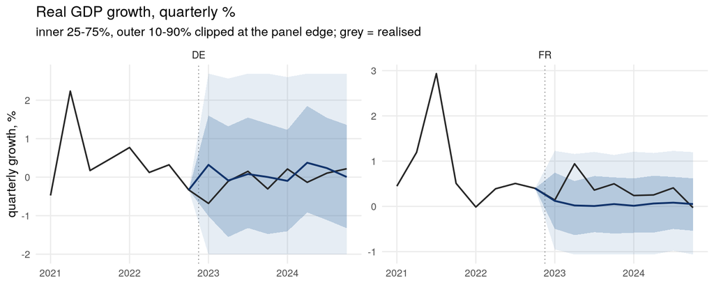

Median GDP growth forecast by quarter, percent.

| quarter | DE | FR |
| --- | --- | --- |
| 2023Q1 | 0.32 | 0.12 |
| 2023Q2 | -0.09 | 0.02 |
| 2023Q3 | 0.08 | 0.01 |
| 2023Q4 | 0.00 | 0.05 |
| 2024Q1 | -0.10 | 0.01 |
| 2024Q2 | 0.37 | 0.06 |
| 2024Q3 | 0.23 | 0.08 |
| 2024Q4 | 0.01 | 0.05 |

### Prices

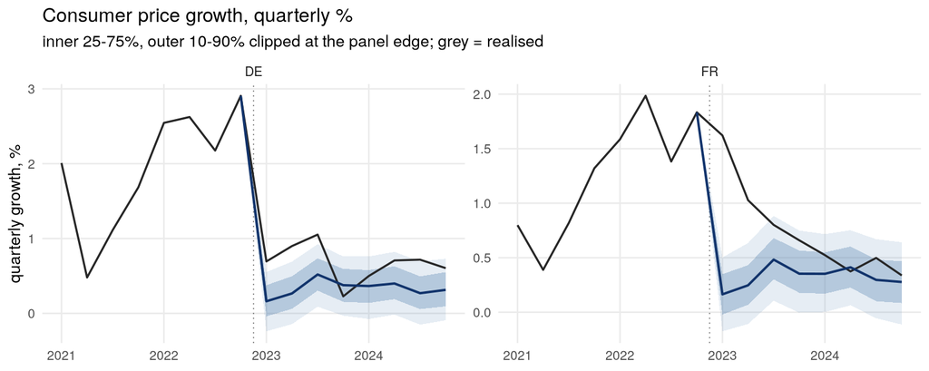

Median price growth forecast by quarter, percent.

| quarter | DE | FR |
| --- | --- | --- |
| 2023Q1 | 0.16 | 0.16 |
| 2023Q2 | 0.27 | 0.25 |
| 2023Q3 | 0.52 | 0.48 |
| 2023Q4 | 0.38 | 0.35 |
| 2024Q1 | 0.37 | 0.35 |
| 2024Q2 | 0.40 | 0.41 |
| 2024Q3 | 0.27 | 0.30 |
| 2024Q4 | 0.31 | 0.28 |

### Policy rates

A `method = "none"` series passes through koma untouched, so for a policy rate the forecast **is** the level – there is no rate-versus-level distinction to make, and no anchoring question either.

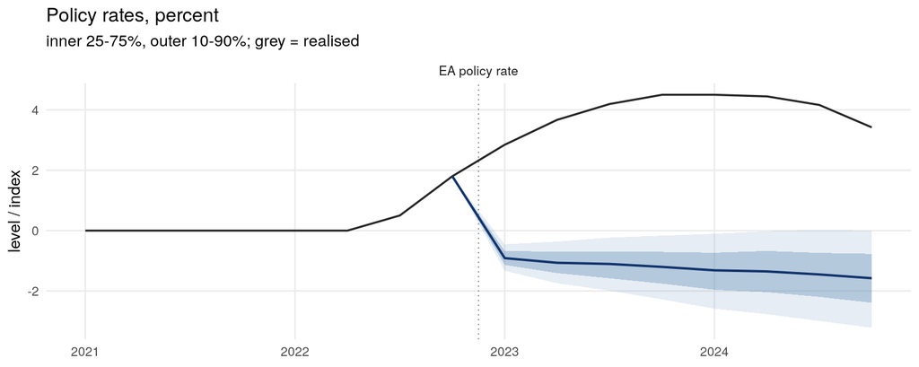

Median policy-rate path, percent.

| quarter | ea_policy_rate |
| --- | --- |
| 2023Q1 | -0.91 |
| 2023Q2 | -1.07 |
| 2023Q3 | -1.11 |
| 2023Q4 | -1.20 |
| 2024Q1 | -1.32 |
| 2024Q2 | -1.35 |
| 2024Q3 | -1.45 |
| 2024Q4 | -1.58 |

### Forecast against outturn

The whole horizon is observed, so the forecast can simply be compared with what happened. This is not a formal backtest – `reports/evaluation.qmd` is, across many origins – but it is the cheapest honest look at whether the stage is producing sensible paths.

GDP growth: median forecast (fc) against outturn (act), percent.

| quarter | DE fc | DE act | FR fc | FR act |
| --- | --- | --- | --- | --- |
| 2023Q1 | 0.32 | -0.68 | 0.12 | 0.14 |
| 2023Q2 | -0.09 | -0.10 | 0.02 | 0.94 |
| 2023Q3 | 0.08 | 0.15 | 0.01 | 0.36 |
| 2023Q4 | 0.00 | -0.31 | 0.05 | 0.50 |
| 2024Q1 | -0.10 | 0.21 | 0.01 | 0.24 |
| 2024Q2 | 0.37 | -0.13 | 0.06 | 0.25 |
| 2024Q3 | 0.23 | 0.10 | 0.08 | 0.41 |
| 2024Q4 | 0.01 | 0.22 | 0.05 | -0.03 |

### What was discarded, and what the exogenous path assumes

Share of posterior draws discarded as explosive, by variable.

| variable | explosive share, h1 | h8 | max |
| --- | --- | --- | --- |
| de_gdp | 0 | 0 | 0 |
| fr_gdp | 0 | 0 | 0 |
| de_prices | 0 | 0 | 0 |
| fr_prices | 0 | 0 | 0 |

The untruncated predictive band at horizon 8 – quarterly growth, percent. This is what the charts clip.

| variable | median | inner_low | inner_high | outer_low | outer_high | outer_width |
| --- | --- | --- | --- | --- | --- | --- |
| de_gdp | 0.0 | -1.3 | 1.4 | -2.7 | 2.7 | 5.4 |
| fr_gdp | 0.1 | -0.5 | 0.6 | -1.1 | 1.2 | 2.3 |
| de_prices | 0.3 | 0.1 | 0.6 | -0.1 | 0.7 | 0.8 |
| fr_prices | 0.3 | 0.1 | 0.5 | -0.1 | 0.6 | 0.7 |

A forecast this long needs the **exogenous** series to reach the end of the horizon, and they do not: every one of them stops at the fit’s own native forecast end. `extend_forecast_horizon()` carries each one forward on its trailing four-quarter average growth – a momentum continuation, not a view on oil markets or world trade – and koma would otherwise have silently returned a shorter horizon than the one requested.

How each exogenous series was carried past the fit’s native forecast end.

| variable | method | periods_added |
| --- | --- | --- |
| eur_usd | trailing-4Q avg growth (2.67%/q) | 4 |
| oil_price | trailing-4Q avg growth (1.41%/q) | 4 |
| de_government | trailing-4Q avg growth (0.89%/q) | 4 |
| row_gdp | trailing-4Q avg growth (0.72%/q) | 4 |
| fr_government | trailing-4Q avg growth (0.29%/q) | 4 |